# Measurement_EffectSize_MA

Mariam Abass

2024-02-27

This script sould be run from the main QMEE directory This script uses the data set “SpeciesStarvation_Cleaned_MA.rds” located in my main QMEE directory

loading the libraries and reading in the dataset

```r
library(tidyverse)
Size_data <- readRDS("SpeciesStarvation_Cleaned_MA.rds")
```

## 1. Measurement

## A)

Theoretical context: The co-evolution of condition dependence and sexual size dimorphism

Empirical relational structure: Because I want to see how the extent of trait differences between the sexes changes in response to decreased developmental condition, I would measure trait size for those expected to exhibit sexual size dimorphism, and traits that are not expected to exhibit biologically relevant size dimorphism which act as our ‘control’. I would measure trait size in males and females in good condition and in poor condition.

Numerical relational structure: The following trait measurements were taken for both sexes in the different cohort levels for all species: tibia length and width, tarsus length and width, thorax length, and wing area.

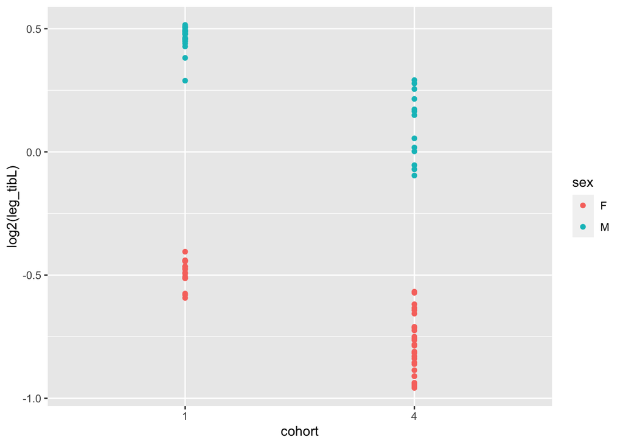

```r
Prolongata_measurements <- Size_data[Size_data$species_full =="D_prolongata",]

print(ggplot(Prolongata_measurements)
              + aes(x = cohort, y = log2(leg_tibL), colour = sex)
      + geom_point())
```

Figure caption: Drosophila prolongata tibia length measurements for each cohort coloured by sex. Cohort one was fully fed. Cohort 4 was starved for approximately 36 hours during development.

Meaningful inference: - The tibia of male D. prolongata is longer than that of the females - D. prolongata males and females that were starved for 36 hours (cohort 4) have shorter tibias than individuals that were fully fed (cohort 1) - The decrease in tibia length after 36 hours of starvation during development appears to be more pronounced in males than in females.

##B) Given that cohort number is on the ordinal scale, meaning that the ordering of the cohorts has meaning, I can compare the change in tibia length from cohort 1 to cohort 4. Given the numbers 1 and 4 signify no starvation and 36 hours of starvation, respectively, reassigning the numbers 1 and 4, to the values high and low condition, would be a meaningful transformation.

Given that the values of tibia length are on the ratio scale, and the distance between values is meaningful, I can interpret larger values as signifying longer tibia. I can therefore interpret smaller values for tibia length in females relative to males as males having longer tibias. I can also compare values across condition levels to comment on the change in tibia length (i.e., longer or shorter tibia). Because tibia length has a natural zero, I can log2 transform the values and comment on the proportional change of tibia length across groups (i.e., across sex or across cohort number/condition level).

##2

##C) Using Hedges’ d is advantageous as there is an established rule of thumb for small, medium, and large effect sizes (d = 0.2, 0.5, 0.8). A standardized benchmark for biological significance of effect sizes makes my results easy to interpret and compare between studies. However, using a rigid definition of ‘significance’ is disadvantageous because it causes researchers to fall into the same trap associated with NHST - That is, ignoring biologically relevant interpretations of our effect sizess simply because our results already seem to adhere to our strict definition of what is and is not ‘significant’ (Nakagawa and Cuthill, 2007).

##D) The benchmarks as proposed by Cohen: d = 0.2, 0.5, 0.8 signify ‘small’, ‘medium’, ‘large’ effect. I will use these same values as a benchmark for my estimates of Hedges’ g and d.

My scale of magnitudes is as follows: - An effect size of g < 0.299 is judged to be not of meaningful biological relevance. - An effect size between 0.3 – 0.699 is in the grey area. - An effect size of g > 0. 7 is judged to be of meaningful biological relevance.

Given what I currently know about measuring phenotypic variation, I do not believe there is any reason to expect effect sizes that are skewed in any specific direction to warrant straying from the already established benchmarks.

Experiment 2: Despite the confidence interval including zero, I would not conclude that the mutant has no biologically relevant effect because I cannot reject the counter-null hypothesis in this case. I would conclude that it is equally likely that the effect of the mutant is biologically relevant as it is that the effect is not biologically relevant - however, I cannot be certain of either scenario.

Experiment 3: I can be fairly certain that the effect of the mutant of the trait of interest of meaningful biological relevance.

Experiment 4: Despite the confidence interval including values that are definitely of practical relevance, because it extends into the grey area, I am hesitant to conclude that the effect of the mutant is definitely of practical relevance. I can conclude with low certainty that the mutant has an effect on the trait of interest that is of meaningful biological relevance.

Experiment 5: Despite the confidence interval extending into both regions of practical relevance and unlikely to be of practical relevance, I am very uncertain that the effect of the mutant is consistent with either conclusion. I cannot make any conclusions about the effect of the mutant on the trait of interest.

Experiment 6: Despite including values that are judged to be not of biological relevance, the confidence interval also extends into the grey area, so I cannot included with certainty that the effect of the mutant on the trait is not biologically relevant. I am not certain that the effect of the mutant on the trait is not biolgically relevant.

Experiment 7: I can be fairly certain that the effect of the mutant on the trait of interest is not biologically relevant.

References

Koricheva, J., Gurevitch, J., & Mengersen, K. (2013). Handbook of meta-analysis in ecology and evolution. Princeton University Press.

Nakagawa, S., & Cuthill, I. C. (2007). Effect size, confidence interval and statistical significance: a practical guide for biologists. Biological Reviews, 82(4), 591–605. https://doi.org/10.1111/j.1469-185x.2007.00027.x